# 05 - Feature engineering

Jens Linden

STATUS: Development

# 1 Management summary

Create analytics base table for hotels and reviews.

The following features have been selected or created:

- Hotel
  - `dist_city_centre`: Distance of hotel to city centre in meters
  - `Total_Number_of_Reviews`: Number of reviews given to hotel as a proxy for the size of the hotel
  - `city`: City of hotel
- Review
  - `month`: Month when review was given
  - `n_nights`: Number of nights the reviewer stayed in the hotel
  - `trip_type`: Whether `business trip` or `leisure trip`. `NA`s set to `unknown` when info missing.
  - `is_mobile_device`: Whether the trip was booked via a mobile device or not (`yes` or `no`)
  - `group_type`: Whether the reviewer travelled alone or in a group. Possible values are `couple`, `solo traveler`,`group`, `family with young children`, `family with older children`, `travelers with friends`, `with a pet`
  - `is_superior_room`: Whether a ‘superior’ room was booked (`yes` or `no`)
  - `room_size`: Size of room booked (`single`, `double` or `family`. `NA`s set to `unknown` when info missing.)

# 2 Inits

Initialisations and loading of libraries required:

```r
rm(list=ls())   # clear all
graphics.off()  # close all
Sys.setenv(LANG = "en")
# Libs
# library(checkpoint) # Package management to avoid incompatibilities; not required when dockerized
# checkpoint('2017-10-01') # Use all packages as of date provided
library(data.table) # Efficient and fast data munging in R; just do it
options(datatable.auto.index=FALSE) # Bug fixing for v < 1.9.5
library(ggplot2) # Good quality plots
library(rprojroot) # Rroot folder management
ROOT <- find_root(has_file("PROJECT_ROOT_DIR"))
library(geosphere) # Compute distance of geospatial data
library(knitr) # Knitting R markdown reports
library(tidyr) # extract numeric from string
library(tm)
source(paste0(ROOT, "/02_code/lib.R"))
options(width = 100)
```

# 3 Load data

```r
(hot <- readRDS(paste0(ROOT, '/01_data/03_preprocessed/hotels.rds')))
```

```
##       id_hot                       Hotel_Name
##    1:      1                      Hotel Arena
##    2:      2                 K K Hotel George
##    3:      3          Apex Temple Court Hotel
##    4:      4 The Park Grand London Paddington
##    5:      5              Monhotel Lounge SPA
##   ---
## 1490:   1490       Suite Hotel 900 m zur Oper
## 1491:   1491                    Hotel Amadeus
## 1492:   1492                     The Berkeley
## 1493:   1493    Holiday Inn London Kensington
## 1494:   1494            Atlantis Hotel Vienna
##                                                                                Hotel_Address
##    1:                               s Gravesandestraat 55 Oost 1092 AA Amsterdam Netherlands
##    2: 1 15 Templeton Place Earl s Court Kensington and Chelsea London SW5 9NB United Kingdom
```

[output cut: 33 more lines]

```r
(rev <- readRDS(paste0(ROOT, '/01_data/03_preprocessed/reviews.rds')))
```

```
##                 Hotel_Name
##      1: 11 Cadogan Gardens
##      2: 11 Cadogan Gardens
##      3: 11 Cadogan Gardens
##      4: 11 Cadogan Gardens
##      5: 11 Cadogan Gardens
##     ---
## 515207:  pentahotel Vienna
## 515208:  pentahotel Vienna
## 515209:  pentahotel Vienna
## 515210:  pentahotel Vienna
## 515211:  pentahotel Vienna
##                                                                                 Hotel_Address
##      1: 11 Cadogan Gardens Sloane Square Kensington and Chelsea London SW3 2RJ United Kingdom
##      2: 11 Cadogan Gardens Sloane Square Kensington and Chelsea London SW3 2RJ United Kingdom
```

[output cut: 129 more lines]

```r
(tag <- readRDS(paste0(ROOT, '/01_data/03_preprocessed/tags.rds')))
```

```
##                                    id_rev                 tag
##       1: 9af46ef4d7ed3c837dc0fd672dbc3b7f        leisure trip
##       2: 9af46ef4d7ed3c837dc0fd672dbc3b7f              couple
##       3: 9af46ef4d7ed3c837dc0fd672dbc3b7f superior queen room
##       4: 9af46ef4d7ed3c837dc0fd672dbc3b7f      stayed 1 night
##       5: 614888458f352152d1b786abf0b8b510        leisure trip
##      ---
## 2354212: 99aedbdb79cc5eda4b158677efe9386e     stayed 3 nights
## 2354213: e36e77529dbbe2719deb0170dcee39b4        leisure trip
## 2354214: e36e77529dbbe2719deb0170dcee39b4              couple
## 2354215: e36e77529dbbe2719deb0170dcee39b4     penta plus room
## 2354216: e36e77529dbbe2719deb0170dcee39b4     stayed 3 nights
```

# 4 Hotel

## 4.1 Distance of hotel from city centre

```r
dist_ <-  distm(hot[, .(lng, lat)], hot[, .(city_lng, city_lat)], fun = distHaversine)
hot[, dist_city_centre := diag(dist_)]
# Inspect
hot[, .(id_hot, Hotel_Address, dist_city_centre)]
```

```
##       id_hot                                                                          Hotel_Address
##    1:      1                               s Gravesandestraat 55 Oost 1092 AA Amsterdam Netherlands
##    2:      2 1 15 Templeton Place Earl s Court Kensington and Chelsea London SW5 9NB United Kingdom
##    3:      3          1 2 Serjeant s Inn Fleet Street City of London London EC4Y 1LL United Kingdom
##    4:      4                     1 3 Queens Garden Westminster Borough London W2 3BA United Kingdom
##    5:      5                                        1 3 Rue d Argentine 16th arr 75116 Paris France
##   ---
## 1490:   1490                                   Wiedner Hauptstra e 44 04 Wieden 1040 Vienna Austria
## 1491:   1491                                    Wildpretmarkt 5 01 Innere Stadt 1010 Vienna Austria
## 1492:   1492          Wilton Place Knightsbridge Westminster Borough London SW1X 7RL United Kingdom
## 1493:   1493                       Wrights Lane Kensington and Chelsea London W8 5SP United Kingdom
## 1494:   1494                           Wurzbachgasse 21 15 Rudolfsheim F nfhaus 1150 Vienna Austria
##       dist_city_centre
##    1:        2330.9926
##    2:        5690.9030
##    3:         777.3218
##    4:        4378.4431
##    5:        4982.8083
##   ---
## 1490:        1855.7287
## 1491:         604.7996
## 1492:        2882.8540
## 1493:        5297.5589
## 1494:        2176.0265
```

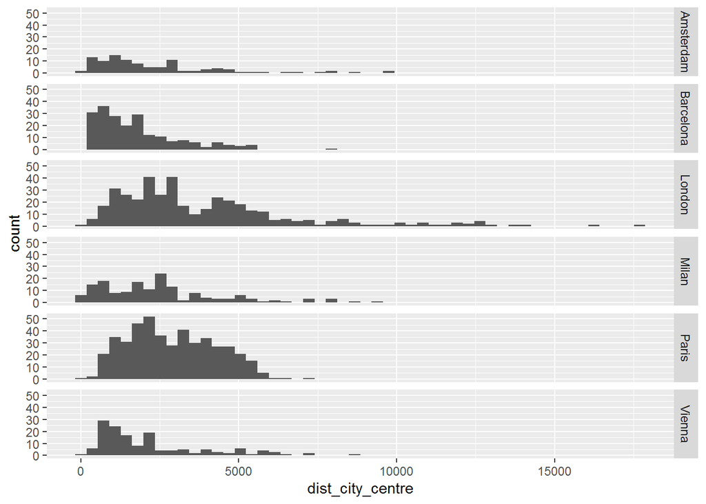

```r
ggplot(hot[!is.na(dist_city_centre)]) +
  geom_histogram(aes(x = dist_city_centre), bins = 50) +
  facet_grid("city") # Looks plausible
```

## 4.2 Size of hotel

Use proxy as number of total reviews given `Total_Number_of_Reviews`.

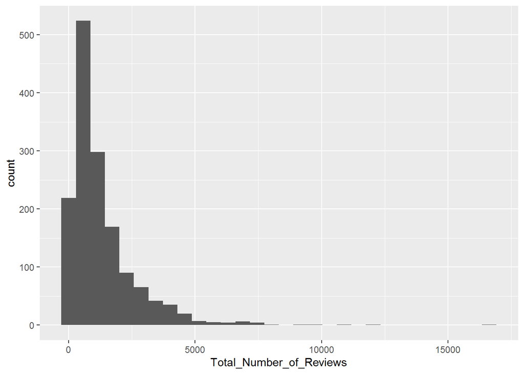

```r
# Inspect
ggplot(hot) + geom_histogram(aes(x = Total_Number_of_Reviews))
```

## 4.3 City

As country and city are identical, choose city

```r
hot[, .N, by = city]
```

```
##         city   N
## 1: Amsterdam 105
## 2:    London 400
## 3:     Paris 455
## 4:      <NA>  17
## 5: Barcelona 208
## 6:     Milan 162
## 7:    Vienna 147
```

## 4.4 Build analytics base table (ABT) for hotels

```r
abt_hot <- hot[, .(id_hot, dist_city_centre, Total_Number_of_Reviews, city)]
abt_hot <- abt_hot[complete.cases(abt_hot)]
print(abt_hot)
```

```
##       id_hot dist_city_centre Total_Number_of_Reviews      city
##    1:      1        2330.9926                    1403 Amsterdam
##    2:      2        5690.9030                    1831    London
##    3:      3         777.3218                    2619    London
##    4:      4        4378.4431                    4380    London
##    5:      5        4982.8083                     171     Paris
##   ---
## 1473:   1490        1855.7287                    3461    Vienna
## 1474:   1491         604.7996                     717    Vienna
## 1475:   1492        2882.8540                     232    London
## 1476:   1493        5297.5589                    5945    London
## 1477:   1494        2176.0265                    2823    Vienna
```

## 4.5 Open points

The following features should be considered in the future to obtain comparable cluster of hotels:

- Stars: Category of hotel (e.g. 5 stars) is already a comparison indicator and should be utilized to determine peer hotels
- Price: Average room price of hotel

# 5 Reviews

## 5.1 Initialise ABT with month

```r
abt_rev <- rev[, .(id_rev, id_hot, month = format(Review_Date,"%B"))]
```

## 5.2 From tags

Get stats

```r
(tag_stats <- tag[, .N, by = tag][order(N, decreasing = T)])
```

```
##                                                        tag      N
##    1:                                         leisure trip 417354
##    2:                       submitted from a mobile device 307355
##    3:                                               couple 252005
##    4:                                       stayed 1 night 193497
##    5:                                      stayed 2 nights 133808
##   ---
## 2417:                    special offer classic double room      1
## 2418: deluxe double room with balcony and free pool access      1
## 2419:                    suite with balcony and spa access      1
## 2420:                         art room xl with iconic view      1
## 2421:                                penta playerpad suite      1
```

### 5.2.1 Number of stayed nights

```r
# Inspect
tag_stats[grepl(pattern = "stayed", x = tag)]
```

```
##                  tag      N
##  1:   stayed 1 night 193497
##  2:  stayed 2 nights 133808
##  3:  stayed 3 nights  95706
##  4:  stayed 4 nights  47750
##  5:  stayed 5 nights  20818
##  6:  stayed 6 nights   9754
##  7:  stayed 7 nights   7387
##  8:  stayed 8 nights   2498
##  9:  stayed 9 nights   1293
## 10: stayed 10 nights    887
## 11: stayed 11 nights    417
## 12: stayed 12 nights    316
## 13: stayed 14 nights    247
## 14: stayed 13 nights    246
```

[output cut: 18 more lines]

```r
# Extract number of nights
tag[grepl(pattern = "stayed", x = tag),
    n_nights := extract_numeric(tag)]
```

```
## extract_numeric() is deprecated: please use readr::parse_number() instead
```

```r
# Plausicheck
print(tag) # Visual
```

```
##                                    id_rev                 tag n_nights
##       1: 9af46ef4d7ed3c837dc0fd672dbc3b7f        leisure trip       NA
##       2: 9af46ef4d7ed3c837dc0fd672dbc3b7f              couple       NA
##       3: 9af46ef4d7ed3c837dc0fd672dbc3b7f superior queen room       NA
##       4: 9af46ef4d7ed3c837dc0fd672dbc3b7f      stayed 1 night        1
##       5: 614888458f352152d1b786abf0b8b510        leisure trip       NA
##      ---
## 2354212: 99aedbdb79cc5eda4b158677efe9386e     stayed 3 nights        3
## 2354213: e36e77529dbbe2719deb0170dcee39b4        leisure trip       NA
## 2354214: e36e77529dbbe2719deb0170dcee39b4              couple       NA
## 2354215: e36e77529dbbe2719deb0170dcee39b4     penta plus room       NA
## 2354216: e36e77529dbbe2719deb0170dcee39b4     stayed 3 nights        3
```

```r
tag[!is.na(n_nights)][, sum(duplicated(id_rev))] # ok, only one night tag for each review
```

```
## [1] 0
```

```r
# Add to abt
(abt_rev <- merge(abt_rev,
                 tag[!is.na(n_nights), .(id_rev, n_nights)],
                 by = 'id_rev',
                 all.x = T))
```

```
##                                   id_rev id_hot    month n_nights
##      1: 0000021f16f34e83f3c00f7c1e8ce342    424  Februar        1
##      2: 00001a70c8aafd8b629de382a9e56a5d    981      Mai        8
##      3: 000026bf2118dd993ac3fe193e44bc66    487     März        1
##      4: 00002f5267fe6e9f4ed0d3c31a4d6388   1025 Dezember        2
##      5: 00003e7067fd3c681b86f6d576b1f03d    617     Juli        1
##     ---
## 515207: ffff3c0921d9a8e3bbff7bcf28053d5a   1124   August        2
## 515208: ffff5c19d56ee3324f2c1bc030324ea2    310 Dezember        2
## 515209: ffff6193b3e00f992a63a3c812e9137e   1178     Juli        3
## 515210: ffff82261013e152f41cb939f0121401    799     Juli        3
## 515211: ffffc8f6f66e7beccec01579237ae668   1021     Juli        2
```

Cleanup

```r
# Remove used tags
tag <- tag[!grepl(pattern = "stayed", x = tag)]
tag$n_nights <- NULL
# Recompute tag statistics
(tag_stats <- tag[, .N, by = tag][order(N, decreasing = T)])
```

```
##                                                        tag      N
##    1:                                         leisure trip 417354
##    2:                       submitted from a mobile device 307355
##    3:                                               couple 252005
##    4:                                        solo traveler 108431
##    5:                                        business trip  82853
##   ---
## 2386:                    special offer classic double room      1
## 2387: deluxe double room with balcony and free pool access      1
## 2388:                    suite with balcony and spa access      1
## 2389:                         art room xl with iconic view      1
## 2390:                                penta playerpad suite      1
```

### 5.2.2 Trip type

Whether leisure or business

```r
# Check tag labels
tag_stats[!grepl(pattern = "triple", x = tag) & grepl(pattern = "trip", x = tag)]
```

```
##              tag      N
## 1:  leisure trip 417354
## 2: business trip  82853
```

```r
# Plausicheck
tag[tag %in% c('leisure trip', 'business trip')][, sum(duplicated(id_rev))] # ok, only one type for each review
```

```
## [1] 0
```

```r
# Add to abt
(abt_rev <- merge(abt_rev,
                 tag[tag %in% c('leisure trip', 'business trip'), .(id_rev, trip_type = tag)],
                 by = 'id_rev',
                 all.x = T))
```

```
##                                   id_rev id_hot    month n_nights     trip_type
##      1: 0000021f16f34e83f3c00f7c1e8ce342    424  Februar        1 business trip
##      2: 00001a70c8aafd8b629de382a9e56a5d    981      Mai        8 business trip
##      3: 000026bf2118dd993ac3fe193e44bc66    487     März        1  leisure trip
##      4: 00002f5267fe6e9f4ed0d3c31a4d6388   1025 Dezember        2  leisure trip
##      5: 00003e7067fd3c681b86f6d576b1f03d    617     Juli        1 business trip
##     ---
## 515207: ffff3c0921d9a8e3bbff7bcf28053d5a   1124   August        2          <NA>
## 515208: ffff5c19d56ee3324f2c1bc030324ea2    310 Dezember        2  leisure trip
## 515209: ffff6193b3e00f992a63a3c812e9137e   1178     Juli        3  leisure trip
## 515210: ffff82261013e152f41cb939f0121401    799     Juli        3  leisure trip
## 515211: ffffc8f6f66e7beccec01579237ae668   1021     Juli        2  leisure trip
```

```r
# Set NA to 'unknown'
abt_rev[is.na(trip_type)]
```

```
##                                  id_rev id_hot    month n_nights trip_type
##     1: 0001a44a636d2fa3bedc387cdb8bfff4     88      Mai        1      <NA>
##     2: 00196f6045ede5d95da9fa0c9f6f3a02    357  Oktober        1      <NA>
##     3: 001ae38e8e5d96402ec8719a05300e14    449   August        2      <NA>
##     4: 001fb1585b1d5ff4815edc79382b9d75    710     Juni        2      <NA>
##     5: 00237e6982210ae1b59f4ed8c692d100    195  Februar        1      <NA>
##    ---
## 15000: fffab1d2911ae3aa854af5fef1a3c6fd   1201  Februar        2      <NA>
## 15001: fffbc37a69192ec3e20c799cd986436c    931   Januar        3      <NA>
## 15002: fffc66cce758f0adb232a95695c21aa6    503   Januar        3      <NA>
## 15003: fffc7d4507d29131881f49280033c6a7    234 Dezember        1      <NA>
## 15004: ffff3c0921d9a8e3bbff7bcf28053d5a   1124   August        2      <NA>
```

```r
abt_rev[is.na(trip_type), trip_type := 'unknown']
# Inspect
print(abt_rev[1:3])
```

```
##                              id_rev id_hot   month n_nights     trip_type
## 1: 0000021f16f34e83f3c00f7c1e8ce342    424 Februar        1 business trip
## 2: 00001a70c8aafd8b629de382a9e56a5d    981     Mai        8 business trip
## 3: 000026bf2118dd993ac3fe193e44bc66    487    März        1  leisure trip
```

Cleanup

```r
# Remove tags used
tag <- tag[tag %ni% c('leisure trip', 'business trip')]
# Recompute tag statistics
(tag_stats <- tag[, .N, by = tag][order(N, decreasing = T)])
```

```
##                                                        tag      N
##    1:                       submitted from a mobile device 307355
##    2:                                               couple 252005
##    3:                                        solo traveler 108431
##    4:                                                group  65337
##    5:                           family with young children  60975
##   ---
## 2384:                    special offer classic double room      1
## 2385: deluxe double room with balcony and free pool access      1
## 2386:                    suite with balcony and spa access      1
## 2387:                         art room xl with iconic view      1
## 2388:                                penta playerpad suite      1
```

### 5.2.3 Mobile device booker

```r
# Check tag labels
tag_stats[grepl(pattern = "device", x = tag) ]
```

```
##                               tag      N
## 1: submitted from a mobile device 307355
```

```r
tag[grepl(pattern = "device", x = tag)][, sum(duplicated(id_rev))]
```

```
## [1] 0
```

```r
# Add to abt
ids_mobile <- tag[tag %in% c('submitted from a mobile device'), id_rev]
abt_rev[id_rev %in% ids_mobile, is_mobile_device := 'yes']
abt_rev[id_rev %ni% ids_mobile, is_mobile_device := 'no']
# Inspect
abt_rev[1:3]
```

```
##                              id_rev id_hot   month n_nights     trip_type is_mobile_device
## 1: 0000021f16f34e83f3c00f7c1e8ce342    424 Februar        1 business trip               no
## 2: 00001a70c8aafd8b629de382a9e56a5d    981     Mai        8 business trip              yes
## 3: 000026bf2118dd993ac3fe193e44bc66    487    März        1  leisure trip              yes
```

```r
abt_rev[, .N, by = is_mobile_device]
```

```
##    is_mobile_device      N
## 1:               no 207856
## 2:              yes 307355
```

Cleanup

```r
# Remove tags used
tag <- tag[tag %ni% c('submitted from a mobile device')]
# Recompute tag statistics
(tag_stats <- tag[, .N, by = tag][order(N, decreasing = T)])
```

```
##                                                        tag      N
##    1:                                               couple 252005
##    2:                                        solo traveler 108431
##    3:                                                group  65337
##    4:                           family with young children  60975
##    5:                                          double room  35207
##   ---
## 2383:                    special offer classic double room      1
## 2384: deluxe double room with balcony and free pool access      1
## 2385:                    suite with balcony and spa access      1
## 2386:                         art room xl with iconic view      1
## 2387:                                penta playerpad suite      1
```

### 5.2.4 Group type

```r
# Show remaining tags, which do not contain room
tag_stats[!grepl(pattern = "room", x = tag), ][1:20]
```

```
##                             tag      N
##  1:                      couple 252005
##  2:               solo traveler 108431
##  3:                       group  65337
##  4:  family with young children  60975
##  5:  family with older children  26320
##  6:                junior suite   4554
##  7:      travelers with friends   2143
##  8:                       suite   1897
##  9:               deluxe double   1634
## 10:                  with a pet   1405
## 11:                    standard   1231
## 12:                      studio    986
## 13:          studio king family    925
## 14:                studio suite    728
## 15:             standard double    722
## 16:        studio double family    506
## 17:         superior shard king    402
## 18: deluxe with two double beds    391
## 19: double or twin ground floor    384
## 20:                luxury suite    303
```

```r
# Define relevant tags for group type
tags_group <- c('couple',
               'solo traveler',
               'group',
               'family with young children',
               'family with older children',
               'travelers with friends',
               'with a pet')
# Check duplicates
tag[tag %in% tags_group][, sum(duplicated(id_rev))]
```

```
## [1] 1405
```

```r
# Yes, multiple choices are possible. However, only a few, so ignore
(abt_rev <- merge(abt_rev,
                 tag[tag %in% tags_group][!duplicated(id_rev)][, .(id_rev, group_type = tag)],
                 by = 'id_rev',
                 all.x = T))
```

```
##                                   id_rev id_hot    month n_nights     trip_type is_mobile_device
##      1: 0000021f16f34e83f3c00f7c1e8ce342    424  Februar        1 business trip               no
##      2: 00001a70c8aafd8b629de382a9e56a5d    981      Mai        8 business trip              yes
##      3: 000026bf2118dd993ac3fe193e44bc66    487     März        1  leisure trip              yes
##      4: 00002f5267fe6e9f4ed0d3c31a4d6388   1025 Dezember        2  leisure trip              yes
##      5: 00003e7067fd3c681b86f6d576b1f03d    617     Juli        1 business trip               no
##     ---
## 515207: ffff3c0921d9a8e3bbff7bcf28053d5a   1124   August        2       unknown              yes
## 515208: ffff5c19d56ee3324f2c1bc030324ea2    310 Dezember        2  leisure trip               no
## 515209: ffff6193b3e00f992a63a3c812e9137e   1178     Juli        3  leisure trip              yes
## 515210: ffff82261013e152f41cb939f0121401    799     Juli        3  leisure trip               no
## 515211: ffffc8f6f66e7beccec01579237ae668   1021     Juli        2  leisure trip              yes
##                         group_type
##      1:              solo traveler
##      2:              solo traveler
##      3:                     couple
##      4:                     couple
##      5:              solo traveler
##     ---
## 515207: family with young children
## 515208:                      group
## 515209:                     couple
## 515210:                     couple
## 515211:                     couple
```

```r
# Any NAs?
abt_rev[is.na(group_type)] # No, good! Group type was specified for each review.
```

```
## Empty data.table (0 rows and 7 cols): id_rev,id_hot,month,n_nights,trip_type,is_mobile_device...
```

Cleanup

```r
# Remove tags used
tag <- tag[tag %ni% tags_group]
rm(tags_group)
# Recompute tag statistics
(tag_stats <- tag[, .N, by = tag][order(N, decreasing = T)])
```

```
##                                                        tag     N
##    1:                                          double room 35207
##    2:                                 standard double room 32245
##    3:                                 superior double room 31330
##    4:                                   deluxe double room 24804
##    5:                                  double or twin room 22393
##   ---
## 2376:                    special offer classic double room     1
## 2377: deluxe double room with balcony and free pool access     1
## 2378:                    suite with balcony and spa access     1
## 2379:                         art room xl with iconic view     1
## 2380:                                penta playerpad suite     1
```

### 5.2.5 Superior room

```r
# Inspect tags indicating superior
tag_stats[grepl(pattern = "superior", x = tag) |
           grepl(pattern = "deluxe", x = tag) , ]
```

```
##                                                       tag     N
##   1:                                 superior double room 31330
##   2:                                   deluxe double room 24804
##   3:                         superior double or twin room 13570
##   4:                                   superior twin room  6051
##   5:                           deluxe double or twin room  6003
##  ---
## 620:                 superior room with sofa bed 4 adults     1
## 621:                 superior room with sofa bed 3 adults     1
## 622:                    minsters deluxe one bedroom suite     1
## 623:                     superior junior suite single use     1
## 624: deluxe double room with balcony and free pool access     1
```

```r
tag_stats[grepl(pattern = "executive", x = tag) , ]
```

```
##                                             tag    N
##   1:                      executive double room 6425
##   2:                        executive king room 2631
##   3:              executive double or twin room 1395
##   4:                             executive room 1293
##   5:                        executive twin room 1080
##  ---
## 228: executive double or twin room with terrace    1
## 229:         easter special executive king room    1
## 230:                       grand executive room    1
## 231:        grand executive room with city view    1
## 232:    park suite with executive lounge access    1
```

```r
tag_stats[grepl(pattern = "king room", x = tag) |
           grepl(pattern = "queen room", x = tag) , ]
```

```
##                                                              tag    N
##   1:                                                  queen room 5472
##   2:                                            deluxe king room 5357
##   3:                                         superior queen room 4897
##   4:                                          superior king room 4248
##   5:                                         standard queen room 3533
##  ---
## 170:                              prestige king room non smoking    1
## 171:                                executive premium queen room    1
## 172: king room balcony with view on eiffel tower view free wi fi    1
## 173:                            urban queen room with spa access    1
## 174:                          easter special executive king room    1
```

```r
tag_stats[grepl(pattern = "king suite", x = tag) |
           grepl(pattern = "queen suite", x = tag) , ]
```

```
##                                                     tag   N
##  1:                  superior queen suite with sofa bed 138
##  2:                      superior queen suite with sofa  69
##  3:                                   junior king suite  58
##  4:                       king suite with lounge access  44
##  5:                                          king suite  38
##  6:         superior queen suite with sofa bed 2 adults  29
##  7:                             one bedroom queen suite  28
##  8:                one bedroom king suite with sofa bed  27
##  9:                      queen suite with lounge access  24
## 10:                junior king suite with view 2 adults  16
## 11:                              one bedroom king suite  14
## 12:             superior queen suite with sofa 3 adults  13
## 13:                king suite with sofa bed non smoking  11
## 14:                                         queen suite  10
```

[output cut: 27 more lines]

```r
# Define flag for superior
tag[grepl(pattern = "superior", x = tag) |
      grepl(pattern = "deluxe", x = tag) |
      grepl(pattern = "executive", x = tag) |
      grepl(pattern = "king room", x = tag) |
      grepl(pattern = "queen room", x = tag) |
      grepl(pattern = "king suite", x = tag) |
      grepl(pattern = "queen suite", x = tag),
    is_superior_room := 'yes']
print(tag)
```

```
##                                   id_rev                 tag is_superior_room
##      1: 9af46ef4d7ed3c837dc0fd672dbc3b7f superior queen room              yes
##      2: 614888458f352152d1b786abf0b8b510 superior queen room              yes
##      3: 8d106f30bf2a76941b71b93ed8b6daa5         single room             <NA>
##      4: d17ecf18be240ae67e89bbdf621a5e53 superior queen room              yes
##      5: 2ef6cc28c2805fedd9d0e233f82b8092 superior queen room              yes
##     ---
## 515015: f42f0cabfbcaf4e08dda75c7fa495bc0 penta standard room             <NA>
## 515016: 4971525a98a06f1f03c6d077c91a6e68  penta junior suite             <NA>
## 515017: f24205a92db9073ff4e385ff06760657     penta plus room             <NA>
## 515018: 99aedbdb79cc5eda4b158677efe9386e penta standard room             <NA>
## 515019: e36e77529dbbe2719deb0170dcee39b4     penta plus room             <NA>
```

```r
# Check
tag[is_superior_room == 'yes', sum(duplicated(id_rev))] # good, no dups
```

```
## [1] 0
```

```r
# Add to abt
(abt_rev <- merge(abt_rev,
                 tag[is_superior_room == 'yes', .(id_rev, is_superior_room)],
                 by = 'id_rev',
                 all.x = T))
```

```
##                                   id_rev id_hot    month n_nights     trip_type is_mobile_device
##      1: 0000021f16f34e83f3c00f7c1e8ce342    424  Februar        1 business trip               no
##      2: 00001a70c8aafd8b629de382a9e56a5d    981      Mai        8 business trip              yes
##      3: 000026bf2118dd993ac3fe193e44bc66    487     März        1  leisure trip              yes
##      4: 00002f5267fe6e9f4ed0d3c31a4d6388   1025 Dezember        2  leisure trip              yes
##      5: 00003e7067fd3c681b86f6d576b1f03d    617     Juli        1 business trip               no
##     ---
## 515207: ffff3c0921d9a8e3bbff7bcf28053d5a   1124   August        2       unknown              yes
## 515208: ffff5c19d56ee3324f2c1bc030324ea2    310 Dezember        2  leisure trip               no
## 515209: ffff6193b3e00f992a63a3c812e9137e   1178     Juli        3  leisure trip              yes
## 515210: ffff82261013e152f41cb939f0121401    799     Juli        3  leisure trip               no
## 515211: ffffc8f6f66e7beccec01579237ae668   1021     Juli        2  leisure trip              yes
##                         group_type is_superior_room
##      1:              solo traveler             <NA>
##      2:              solo traveler              yes
##      3:                     couple             <NA>
##      4:                     couple             <NA>
##      5:              solo traveler             <NA>
##     ---
## 515207: family with young children             <NA>
## 515208:                      group             <NA>
## 515209:                     couple             <NA>
## 515210:                     couple             <NA>
## 515211:                     couple              yes
```

```r
abt_rev[is.na(is_superior_room), is_superior_room := 'no']
abt_rev[, .N, by = is_superior_room]
```

```
##    is_superior_room      N
## 1:               no 321525
## 2:              yes 193686
```

Cleanup

```r
tag$is_superior_room <- NULL
```

### 5.2.6 Room size

```r
# Inspect
tag_stats[1:50]
```

```
##                                     tag     N
##  1:                         double room 35207
##  2:                standard double room 32245
##  3:                superior double room 31330
##  4:                  deluxe double room 24804
##  5:                 double or twin room 22393
##  6:        standard double or twin room 17463
##  7:                 classic double room 16790
##  8:        superior double or twin room 13570
##  9:                             2 rooms 12380
## 10:                  standard twin room  9745
## 11:                         single room  9665
## 12:                           twin room  8319
## 13:               executive double room  6425
## 14:         classic double or twin room  6093
```

[output cut: 37 more lines]

```r
# Double rooms
(tags_double <- tag_stats[grepl(pattern = "double", x = tag) |
                           grepl(pattern = "twin", x = tag), tag])
```

```
##   [1] "double room"
##   [2] "standard double room"
##   [3] "superior double room"
##   [4] "deluxe double room"
##   [5] "double or twin room"
##   [6] "standard double or twin room"
##   [7] "classic double room"
##   [8] "superior double or twin room"
##   [9] "standard twin room"
##  [10] "twin room"
##  [11] "executive double room"
##  [12] "classic double or twin room"
##  [13] "superior twin room"
##  [14] "deluxe double or twin room"
##  [15] "club double room"
```

[output cut: 974 more lines]

```r
tag[tag %in% tags_double, room_size := 'double']
# Single rooms
tag[grepl(pattern = "single room", x = tag) |
      grepl(pattern = "single suite", x = tag), room_size := 'single']
# Family rooms
tag_stats[grepl(pattern = "family", x = tag)]
```

```
##                                                  tag    N
##   1:                                     family room 2165
##   2:                 family room 2 adults 2 children  926
##   3:                              studio king family  925
##   4:                            studio double family  506
##   5:                           executive family room  304
##  ---
## 104:          deluxe family room 2 adults 2 children    1
## 105: standard family suite with two connecting rooms    1
## 106:       family room two connecting rooms 3 adults    1
## 107:                            family room 6 adults    1
## 108:       family room with view 2 adults 2 children    1
```

```r
tag[grepl(pattern = "family", x = tag), room_size := 'family']
# Check dups
tag[!is.na(room_size), sum(duplicated(id_rev))] # No duplicates, good.
```

```
## [1] 0
```

```r
# Add to abt
(abt_rev <- merge(abt_rev,
                 tag[!is.na(room_size), .(id_rev, room_size)],
                 by = 'id_rev',
                 all.x = T))
```

```
##                                   id_rev id_hot    month n_nights     trip_type is_mobile_device
##      1: 0000021f16f34e83f3c00f7c1e8ce342    424  Februar        1 business trip               no
##      2: 00001a70c8aafd8b629de382a9e56a5d    981      Mai        8 business trip              yes
##      3: 000026bf2118dd993ac3fe193e44bc66    487     März        1  leisure trip              yes
##      4: 00002f5267fe6e9f4ed0d3c31a4d6388   1025 Dezember        2  leisure trip              yes
##      5: 00003e7067fd3c681b86f6d576b1f03d    617     Juli        1 business trip               no
##     ---
## 515207: ffff3c0921d9a8e3bbff7bcf28053d5a   1124   August        2       unknown              yes
## 515208: ffff5c19d56ee3324f2c1bc030324ea2    310 Dezember        2  leisure trip               no
## 515209: ffff6193b3e00f992a63a3c812e9137e   1178     Juli        3  leisure trip              yes
## 515210: ffff82261013e152f41cb939f0121401    799     Juli        3  leisure trip               no
## 515211: ffffc8f6f66e7beccec01579237ae668   1021     Juli        2  leisure trip              yes
##                         group_type is_superior_room room_size
##      1:              solo traveler               no    double
##      2:              solo traveler              yes    single
##      3:                     couple               no    double
##      4:                     couple               no    double
##      5:              solo traveler               no    double
##     ---
## 515207: family with young children               no    double
## 515208:                      group               no      <NA>
## 515209:                     couple               no    double
## 515210:                     couple               no    double
## 515211:                     couple              yes    double
```

```r
abt_rev[is.na(room_size), room_size := 'unknown']
print(abt_rev)
```

```
##                                   id_rev id_hot    month n_nights     trip_type is_mobile_device
##      1: 0000021f16f34e83f3c00f7c1e8ce342    424  Februar        1 business trip               no
##      2: 00001a70c8aafd8b629de382a9e56a5d    981      Mai        8 business trip              yes
##      3: 000026bf2118dd993ac3fe193e44bc66    487     März        1  leisure trip              yes
##      4: 00002f5267fe6e9f4ed0d3c31a4d6388   1025 Dezember        2  leisure trip              yes
##      5: 00003e7067fd3c681b86f6d576b1f03d    617     Juli        1 business trip               no
##     ---
## 515207: ffff3c0921d9a8e3bbff7bcf28053d5a   1124   August        2       unknown              yes
## 515208: ffff5c19d56ee3324f2c1bc030324ea2    310 Dezember        2  leisure trip               no
## 515209: ffff6193b3e00f992a63a3c812e9137e   1178     Juli        3  leisure trip              yes
## 515210: ffff82261013e152f41cb939f0121401    799     Juli        3  leisure trip               no
## 515211: ffffc8f6f66e7beccec01579237ae668   1021     Juli        2  leisure trip              yes
##                         group_type is_superior_room room_size
##      1:              solo traveler               no    double
##      2:              solo traveler              yes    single
##      3:                     couple               no    double
##      4:                     couple               no    double
##      5:              solo traveler               no    double
##     ---
## 515207: family with young children               no    double
## 515208:                      group               no   unknown
## 515209:                     couple               no    double
## 515210:                     couple               no    double
## 515211:                     couple              yes    double
```

```r
# Plausichecks
abt_rev[, .N, by = room_size]
```

```
##    room_size      N
## 1:    double 348615
## 2:    single  23951
## 3:   unknown 134028
## 4:    family   8617
```

```r
ids_unkn <- abt_rev[room_size == 'unknown', id_rev]
# Cross check in review data
rev[id_rev %in% ids_unkn, .(tag_split)] # Looks indeed, that from some review tags, the room size cannot be deduced
```

```
##                                                                                                                tag_split
##      1:                                      [' Leisure trip ', ' Couple ', ' Superior Queen Room ', ' Stayed 1 night ']
##      2: [' Leisure trip ', ' Couple ', ' Superior Queen Room ', ' Stayed 3 nights ', ' Submitted from a mobile device ']
##      3: [' Leisure trip ', ' Couple ', ' Superior Queen Room ', ' Stayed 3 nights ', ' Submitted from a mobile device ']
##      4: [' Leisure trip ', ' Couple ', ' Superior Queen Room ', ' Stayed 2 nights ', ' Submitted from a mobile device ']
##      5:  [' Leisure trip ', ' Group ', ' Superior Queen Room ', ' Stayed 2 nights ', ' Submitted from a mobile device ']
##     ---
## 134024:  [' Leisure trip ', ' Group ', ' penta Standard Room ', ' Stayed 3 nights ', ' Submitted from a mobile device ']
## 134025:                                       [' Leisure trip ', ' Group ', ' penta Junior Suite ', ' Stayed 3 nights ']
## 134026:      [' Leisure trip ', ' Group ', ' penta Plus Room ', ' Stayed 4 nights ', ' Submitted from a mobile device ']
## 134027:                                     [' Leisure trip ', ' Couple ', ' penta Standard Room ', ' Stayed 3 nights ']
## 134028:                                         [' Leisure trip ', ' Couple ', ' penta Plus Room ', ' Stayed 3 nights ']
```

Cleanup

```r
rm(ids_unkn)
tag$room_size <- NULL
tag <- tag[!(grepl(pattern = "room", x = tag) |
      grepl(pattern = "suite", x = tag))]
# Recompute tag statistics
(tag_stats <- tag[, .N, by = tag][order(N, decreasing = T)])
```

```
##                                     tag    N
##   1:                      deluxe double 1634
##   2:                           standard 1231
##   3:                             studio  986
##   4:                 studio king family  925
##   5:                    standard double  722
##  ---
## 187:                    double standard    1
## 188:             studio with spa access    1
## 189:                townhouse apartment    1
## 190:                          king loft    1
## 191: twin grand premier with canal view    1
```

```r
tag_stats[1:50]
```

```
##                                       tag    N
##  1:                         deluxe double 1634
##  2:                              standard 1231
##  3:                                studio  986
##  4:                    studio king family  925
##  5:                       standard double  722
##  6:                  studio double family  506
##  7:                   superior shard king  402
##  8:           deluxe with two double beds  391
##  9:           double or twin ground floor  384
## 10:                              superior  270
## 11:                         double studio  269
## 12:                       superior double  236
## 13:                         studio triple  230
## 14:              deluxe king with balcony  213
```

[output cut: 37 more lines]

```r
# Most tags processed, leave it here.
```

## 5.3 Open points

Extract features from review texts, e.g. taking most frequent keywords for each hotel with positive and negative reviews, respectively.

# 6 Save data

```r
saveRDS(abt_hot,  paste0(ROOT, '/01_data/03_preprocessed/abt_hot.rds'))
saveRDS(abt_rev,  paste0(ROOT, '/01_data/03_preprocessed/abt_rev.rds'))
```